# Peer Assesment

Pratigya Subedi

February 7, 2016

# Introduction

This report makes use of data from a personal activity monitoring device. This device collects data at 5 minute intervals through out the day. The data consists of two months of data from an anonymous individual collected during the months of October and November, 2012 and include the number of steps taken in 5 minute intervals each day.

# Data

[Activity Monitoring Data](https://d396qusza40orc.cloudfront.net/repdata%2Fdata%2Factivity.zip)

The variables included in this dataset are:

- steps: Number of steps taking in a 5-minute interval (missing values are coded as NA)
- date: The date on which the measurement was taken in YYYY-MM-DD format
- interval: Identifier for the 5-minute interval in which measurement was taken

The dataset is stored in a comma-separated-value (CSV) file and there are a total of 17,568 observations in this dataset.

## Loading Data into R

```r
#set file path
filePath <- "F:/Pratssubedi/Coursera-DataScience/Rep Research/repdata-data-activity/activity.csv"
# read file as dataset
activity_data <- read.csv(filePath)
```

## Task 1: What is mean total number of steps taken per day?

- For this part of the assignment, you can ignore the missing values in the dataset.
- Calculate the total number of steps taken per day
- If you do not understand the difference between a histogram and a barplot, research the difference between them.
- Make a histogram of the total number of steps taken each day
- Calculate and report the mean and median of the total number of steps taken per day

We will aggregate the steps for each day and plot a histogram for this.

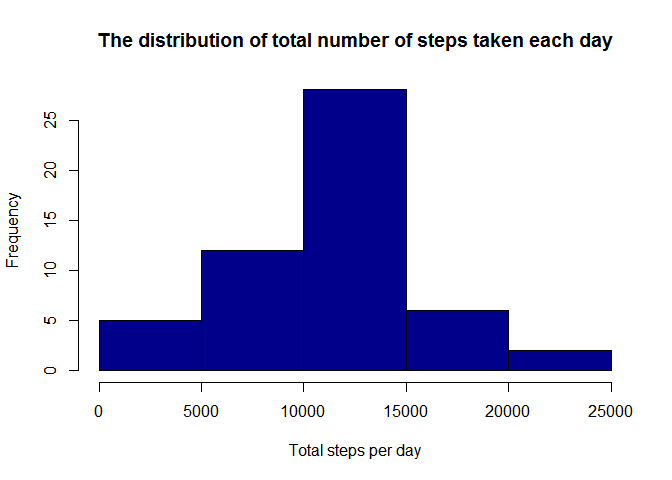

```r
# Get total number of steps for each day
steps_taken_per_day<- aggregate(cbind(activity_data$steps) ~ date, data=activity_data, FUN=sum)
#set proper column names
colnames(steps_taken_per_day) <- c("dates", "total_Steps_Per_Day")

#plot histogram for total number of steps taken each data
hist(x=steps_taken_per_day$total_Steps_Per_Day,
     col="dark blue",
     xlab="Total steps per day",
     ylab="Frequency",
     main="The distribution of total number of steps taken each day")
```

Now calculating the mean and median:

```r
#mean of total steps for each day
mean(steps_taken_per_day$total_Steps_Per_Day)
```

```
## [1] 10766.19
```

```r
#median of total steps for each day
median(steps_taken_per_day$total_Steps_Per_Day)
```

```
## [1] 10765
```

So, the mean is 10766.19 steps and the median is 10765 steps.

## Task 2: What is the average daily activity pattern?

- Next, we will make a time series plot (i.e. type = “l”) of the 5-minute interval (x-axis) and the average number of steps taken, averaged across all days (y-axis)
- Which 5-minute interval, on average across all the days in the dataset, contains the maximum number of steps?

Similar to previous step, we will first aggregate data and plot it.

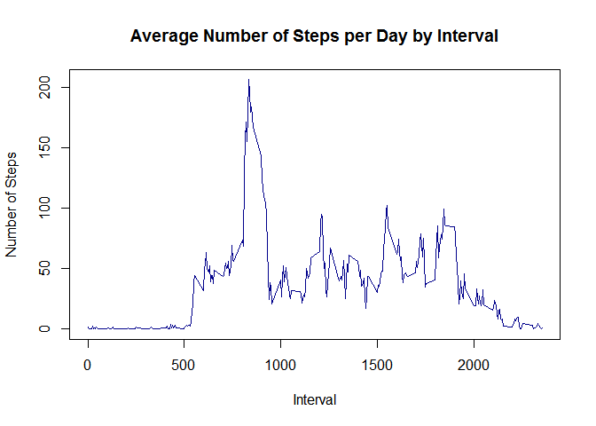

```r
# Get total number of steps for each interval
agg_Steps_By_Intervals <- aggregate(cbind(activity_data$steps) ~ interval, data=activity_data, FUN=mean)
colnames(agg_Steps_By_Intervals) <- c("intervals", "total_Steps_By_Interval")

plot(agg_Steps_By_Intervals$intervals,agg_Steps_By_Intervals$total_Steps_By_Interval, type="l",
     xlab="Interval", ylab="Number of Steps", col="dark blue",
     main="Average Number of Steps per Day by Interval")
```

Now, calculating the maximum interval:

```r
#calculate interval that has the maximum number of steps using which.max function
agg_Steps_By_Intervals[which.max(agg_Steps_By_Intervals$total_Steps_By_Interval),1]
```

```
## [1] 835
```

So interval 835 contains maximum number of steps.